# Project 5: Data Visualization

## Dataset: [Flights](https://docs.google.com/document/d/e/2PACX-1vQmkX4iOT6Rcrin42vslquX2_wQCjIa_hbwD0xmxrERPSOJYDtpNc_3wwK_p9_KpOsfA6QVyEHdxxq7/pub?embedded=True)

## by Andy Soelistio

### Submission Date: January 21, 2019

# Introduction

- I downloaded three years of flight data -- [2006, 2007, and 2008.](http://stat-computing.org/dataexpo/2009/the-data.html). I put them in `raw_data/2006`, `raw_data/2007`, and `raw_data/2008` folder.
- I also downloaded [airports.csv and carriers.csv.](http://stat-computing.org/dataexpo/2009/supplemental-data.html) I put them in `raw_data/supplement` folder.
- I had done an extensive wrangling on the downloaded data prior to this. I did the wrangling inside `wrangling` folder. I separate the wrangling according to years. Please refer to `wrangle_y_2006`, `wrangle_y_2007`, `wrangle_y_2008` inside `wrangling` folder.
- Since the target columns of this project are Departure Delay (DepDelayM) and Arrival Delay (ArrDelayM), I will briefly introduce these columns here.
- Departure Delay Manual (DepDelayM) is measured in minutes.

```python
combined_df.DepDelayM.sample(5)
```

```
113595    42.0
2215       8.0
75949     -4.0
45184     -2.0
51900      0.0
Name: DepDelayM, dtype: float64
```

- Notice that some are negative numbers and some are positive numbers. Positive numbers mean that actual flight took place after scheduled flight. Negative numbers mean that actual flight took place before scheduled flight. Logically positive delays is what we care about. Therefore, I will create one positive departure delay dataframe. I call it pos_dep_delaym_df. Most data come from this dataframe unless otherwise stated.
- Another dataframe is called combined_df. This dataframe contains both positive and negative DepDelayM.
- Arrival Delay Manual (DepDelayM) is measured in minutes.

```python
combined_df.ArrDelayM.sample(5)
```

```
173915    58.0
150220    -7.0
24371     -6.0
20795      0.0
209164   -10.0
Name: ArrDelayM, dtype: float64
```

- Notice that some are negative numbers and some are positive numbers. Positive numbers mean that actual arrival took place after scheduled arrival. Negative numbers mean that actual arrival took place before scheduled arrival. Logically positive delays is what we care about. Therefore, I will create one positive arrival delay dataframe. I call it pos_arr_delaym_df. Most data come from this dataframe unless otherwise stated.
- Another dataframe is called combined_df. This dataframe contains both positive and negative ArrDelayM.

# Univariate Exploration

- Departure Delay Manual (DepDelayM) is measured in minutes.

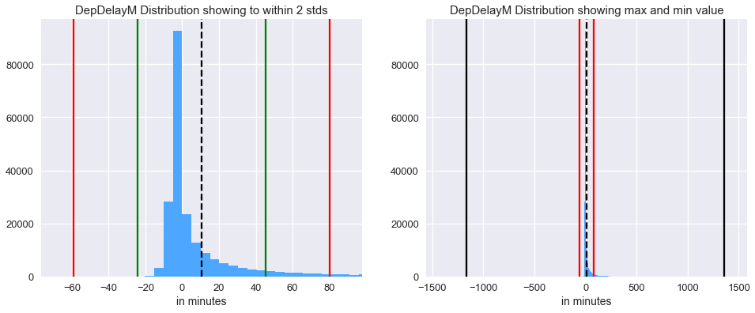

```python
fig = plt.figure(figsize=[16,6])
ax1 = fig.add_subplot(1,2,1)

plt.title('DepDelayM Distribution showing to within 2 stds',fontsize=15)
plt.hist(data=plot_data_df,x='DepDelayM',bins=500);
plt.xlim(plot_data_df.DepDelayM.mean()-(plot_data_df.DepDelayM.std()*2.5),\
             plot_data_df.DepDelayM.mean()+(plot_data_df.DepDelayM.std()*2.5))
plt.axvline(x=plot_data_df.DepDelayM.mean(),color='black',linestyle='--')
plt.axvline(x=plot_data_df.DepDelayM.mean()+plot_data_df.DepDelayM.std(),color='green')
plt.axvline(x=plot_data_df.DepDelayM.mean()+(plot_data_df.DepDelayM.std()*2),color='red')
plt.axvline(x=plot_data_df.DepDelayM.mean()-plot_data_df.DepDelayM.std(),color='green')
plt.axvline(x=plot_data_df.DepDelayM.mean()-(plot_data_df.DepDelayM.std()*2),color='red')
plt.xlabel('in minutes',fontsize=14)

# ==============================

ax2 = fig.add_subplot(1,2,2)
plt.title('DepDelayM Distribution showing max and min value',fontsize=15)
plt.hist(data=plot_data_df,x='DepDelayM',bins=500);
plt.xlim(plot_data_df.DepDelayM.mean()-(plot_data_df.DepDelayM.std()*45),\
             plot_data_df.DepDelayM.mean()+(plot_data_df.DepDelayM.std()*45))
plt.axvline(x=plot_data_df.DepDelayM.mean(),color='black',linestyle='--')
#plt.axvline(x=plot_data.DepDelayM.mean()+plot_data.DepDelayM.std(),color='green')
plt.axvline(x=plot_data_df.DepDelayM.mean()+(plot_data_df.DepDelayM.std()*2),color='red')
#plt.axvline(x=plot_data.DepDelayM.mean()-plot_data.DepDelayM.std(),color='green')
plt.axvline(x=plot_data_df.DepDelayM.mean()-(plot_data_df.DepDelayM.std()*2),color='red')
plt.axvline(x=plot_data_df.DepDelayM.max(),color='black')
plt.axvline(x=plot_data_df.DepDelayM.min(),color='black')
plt.xlabel('in minutes',fontsize=14)

plt.show()
```

- As you can see from the plot above, it is right skewed.
- The second subplot shows that there are points that exist beyond the second stds. Its max value is around 38 stds away!
- I could use the log scale on the x-axis. But log can't handle negative numbers.
- I tried to use symLog scale on the x-axis but I don't think I gain any insights from the plot. Or maybe symLog is beyond my knowledge at this point.
- Instead I break it down into a table with bins. You can find the table below. I find the table insightful.

#### Reflection on outliers

- Outliers are important data.
- I dropped outliers or fill them all with zeros or mean values as I had done in project 2 -- Investigate Dataset. What Project 4 -- We Rate Dogs -- taught me is that although useful data consists of small proportion of total data, I don't drop them all. For example in my project 4 Section D, I don't drop dog type column although only 16.3% of its data is non-null.
- Therefore throughout this project (and my future project), I will not unneccessarily drop columns or rows unless it is really necessary.
- Therefore I will not delete rows even though DepDelayM is 38 stds away from the mean.

```python
for val in combined_df['DepDelayM']:
    if np.isnan(val):
        continue
    else:
        for interval in DepDelayM_interval:
            if val in interval:
                DepDelayM_distro.loc[interval] += 1
                break
DepDelayM_distro
```

```
(-1200, -1140]         1.0
(-1140, -1080]         0.0
(-1080, -1020]         0.0
(-1020, -960]          0.0
(-960, -900]           0.0
(-900, -840]           0.0
(-840, -780]           0.0
(-780, -720]           0.0
(-720, -660]           0.0
(-660, -600]           0.0
(-600, -540]           0.0
(-540, -480]           0.0
(-480, -420]           0.0
(-420, -360]           0.0
(-360, -300]           0.0
(-300, -240]           0.0
(-240, -180]           0.0
(-180, -120]           0.0
(-120, -60]            1.0
(-60, 0]          124174.0
(0, 60]            73751.0
(60, 120]           8717.0
(120, 180]          2585.0
(180, 240]           930.0
(240, 300]           381.0
(300, 360]           137.0
(360, 420]            67.0
(420, 480]            30.0
(480, 540]             9.0
(540, 600]             8.0
(600, 660]             5.0
(660, 720]             2.0
(720, 780]             4.0
(780, 840]             2.0
(840, 900]             1.0
(900, 960]             1.0
(960, 1020]            1.0
(1020, 1080]           1.0
(1080, 1140]           0.0
(1140, 1200]           0.0
(1200, 1260]           2.0
(1260, 1320]           2.0
(1320, 1380]           1.0
(1380, 1440]           0.0
(1440, 1500]           0.0
(1500, 1560]           0.0
(1560, 1620]           0.0
(1620, 1680]           0.0
(1680, 1740]           0.0
(1740, 1800]           0.0
dtype: float64
```

#### From the calculations and table above, we observe the following:

- The bulk of negative Departure Delay (DepDelayM) happened within 60 minutes. There is only one case when the flight is early to within [-1,200, -1,140] minutes.
- Negative Departure Delay consists of around 48% of our data.
- Positive Departure Delay consists of around 40% of our data.
- Almost 4% of our data falls above the second stds. As a proportion this may not seem like a big number but it translates to around 8,000s rows of our data.

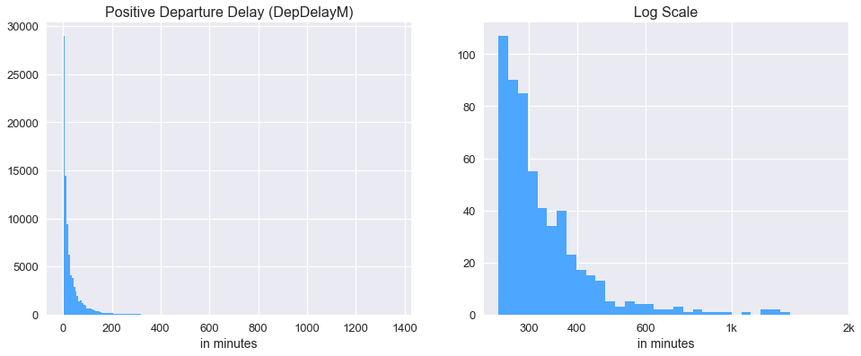

```python
fig = plt.figure(figsize=[16,6])
ax1 = fig.add_subplot(1,2,1)

plt.title('Positive Departure Delay (DepDelayM)',fontsize=16)
plt.hist(data=pos_depdelaym_df,x='DepDelayM',bins=200);
plt.xlabel('in minutes',fontsize=14)

ax2= fig.add_subplot(1,2,2)
plt.title('Log Scale',fontsize=16)
plt.hist(data=pos_depdelaym_df,x='DepDelayM',bins=bins)
plt.xscale('log')
plt.xticks([],minor=True)
plt.xticks([300,400,600,1000,2000],['300','400','600','1k','2k'])
ax2.set_xticklabels([],minor=True)
plt.xlabel('in minutes',fontsize=14)

plt.show()
```

- Because we don't deal with negative numbers, we can use log-scale on positive DepDelayM. It is still right-skewed.
- Arrival Delay Manual (ArrDelayM) is measured in minutes.

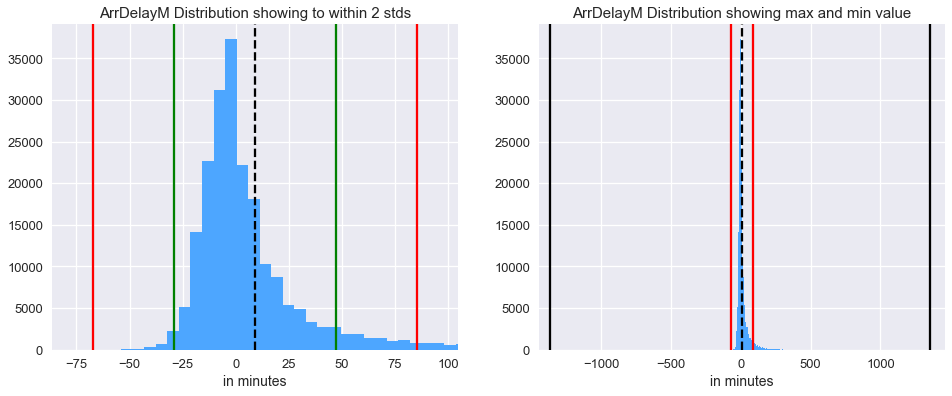

```python
fig = plt.figure(figsize=[16,6])
ax1 = fig.add_subplot(1,2,1)

plt.title('ArrDelayM Distribution showing to within 2 stds',fontsize=15)
plt.hist(data=plot_data_df,x='ArrDelayM',bins=500);
plt.xlim(plot_data_df.ArrDelayM.mean()-(plot_data_df.ArrDelayM.std()*2.5),\
             plot_data_df.ArrDelayM.mean()+(plot_data_df.ArrDelayM.std()*2.5))
plt.axvline(x=plot_data_df.ArrDelayM.mean(),color='black',linestyle='--')
plt.axvline(x=plot_data_df.ArrDelayM.mean()+plot_data_df.ArrDelayM.std(),color='green')
plt.axvline(x=plot_data_df.ArrDelayM.mean()+(plot_data_df.ArrDelayM.std()*2),color='red')
plt.axvline(x=plot_data_df.ArrDelayM.mean()-plot_data_df.ArrDelayM.std(),color='green')
plt.axvline(x=plot_data_df.ArrDelayM.mean()-(plot_data_df.ArrDelayM.std()*2),color='red')
plt.xlabel('in minutes',fontsize=14)

# ==============================

ax2 = fig.add_subplot(1,2,2)
plt.title('ArrDelayM Distribution showing max and min value',fontsize=15)
plt.hist(data=plot_data_df,x='ArrDelayM',bins=500);
plt.xlim(plot_data_df.ArrDelayM.mean()-(plot_data_df.ArrDelayM.std()*38),\
             plot_data_df.ArrDelayM.mean()+(plot_data_df.ArrDelayM.std()*38))
plt.axvline(x=plot_data_df.ArrDelayM.mean(),color='black',linestyle='--')
#plt.axvline(x=plot_data.DepDelayM.mean()+plot_data.DepDelayM.std(),color='green')
plt.axvline(x=plot_data_df.ArrDelayM.mean()+(plot_data_df.ArrDelayM.std()*2),color='red')
#plt.axvline(x=plot_data.DepDelayM.mean()-plot_data.DepDelayM.std(),color='green')
plt.axvline(x=plot_data_df.ArrDelayM.mean()-(plot_data_df.ArrDelayM.std()*2),color='red')
plt.axvline(x=plot_data_df.ArrDelayM.max(),color='black')
plt.axvline(x=plot_data_df.ArrDelayM.min(),color='black')
plt.xlabel('in minutes',fontsize=14)

plt.show()
```

- As you can see from the plot, it is right skewed.
- The second subplot shows that there are points that exist beyond the second stds. Its max value is around 36 stds away!
- I could use the log scale on the x-axis. But log can't handle negative numbers.
- I tried to use symLog scale on the x-axis but I don't think I gain any insights from the plot. Or maybe symLog is beyond my knowledge at this point.
- Instead I break it down into a table with bins. You can find the table below. I find the table insightful.

```python
for val in combined_df['ArrDelayM']:
    if np.isnan(val):
        continue
    else:
        for interval in ArrDelayM_interval:
            if val in interval:
                ArrDelayM_distro.loc[interval] += 1
                break
ArrDelayM_distro
```

```
(-1380, -1320]         1.0
(-1320, -1260]         0.0
(-1260, -1200]         0.0
(-1200, -1140]         1.0
(-1140, -1080]         1.0
(-1080, -1020]         0.0
(-1020, -960]          0.0
(-960, -900]           0.0
(-900, -840]           0.0
(-840, -780]           0.0
(-780, -720]           0.0
(-720, -660]           0.0
(-660, -600]           0.0
(-600, -540]           0.0
(-540, -480]           0.0
(-480, -420]           0.0
(-420, -360]           0.0
(-360, -300]           0.0
(-300, -240]           0.0
(-240, -180]           0.0
(-180, -120]           0.0
(-120, -60]           11.0
(-60, 0]          113909.0
(0, 60]            82147.0
(60, 120]           9602.0
(120, 180]          2874.0
(180, 240]          1045.0
(240, 300]           442.0
(300, 360]           145.0
(360, 420]            73.0
(420, 480]            25.0
(480, 540]            15.0
(540, 600]             4.0
(600, 660]             6.0
(660, 720]             4.0
(720, 780]             3.0
(780, 840]             1.0
(840, 900]             2.0
(900, 960]             1.0
(960, 1020]            1.0
(1020, 1080]           1.0
(1080, 1140]           0.0
(1140, 1200]           1.0
(1200, 1260]           1.0
(1260, 1320]           1.0
(1320, 1380]           1.0
dtype: float64
```

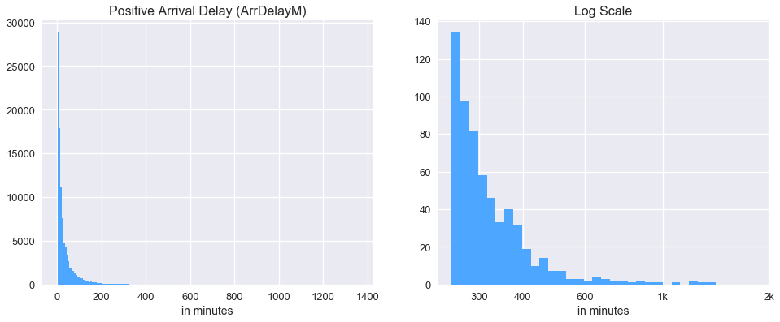

```python
fig = plt.figure(figsize=[16,6])
ax1 = fig.add_subplot(1,2,1)

plt.title('Positive Arrival Delay (ArrDelayM)',fontsize=16)
plt.hist(data=pos_arrdelaym_df,x='ArrDelayM',bins=200);
plt.xlabel('in minutes',fontsize=14)

ax2= fig.add_subplot(1,2,2)
plt.title('Log Scale',fontsize=16)
plt.hist(data=pos_arrdelaym_df,x='ArrDelayM',bins=bins)
plt.xscale('log')
plt.xticks([],minor=True)
plt.xticks([300,400,600,1000,2000],['300','400','600','1k','2k'])
ax2.set_xticklabels([],minor=True)
plt.xlabel('in minutes',fontsize=14)

plt.show()
```

- Because we don't deal with negative numbers, we can use log-scale on positive ArrDelayM. It is still right-skewed.

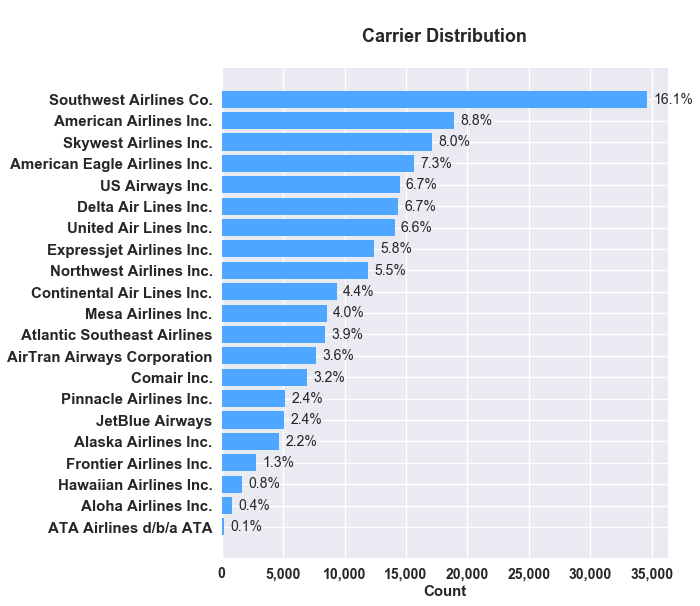

```python
fig = plt.figure(figsize=(8,9))
ax1 = fig.add_subplot(1,1,1)

#plt.barh(combined_df.CarrierDescription.value_counts().index,combined_df.CarrierDescription.value_counts())
plt.barh(carrier_distro.index,carrier_distro.values)
plt.yticks(fontsize=15,weight='bold')
plt.xticks(fontsize=14,rotation=0,weight='bold');
ax1.xaxis.set_major_formatter(mpl.ticker.StrMethodFormatter('{x:,.0f}'));
plt.xlabel('Count',fontsize=15,weight='bold')
plt.title('\nCarrier Distribution\n',fontsize=18,weight='bold');

for i in range(carrier_distro_pct.shape[0]):
    val = carrier_distro_pct.values[i] * 100  # percent
    x_val = carrier_distro.values[i]  # count
    val_str = '{:0.1f}%'.format(val)
    plt.text(x=x_val+500,y=i,s=val_str,va='center',fontsize=14)
```

#### Top Three Carriers

- Southwest Airlines Co. is the top airline in terms of total number flights it made in the dataframe. 16.1% of total flights are made by Southwest Airlines Co. The top three carriers are: Southwest Airlines, American Airlines, and Skywest Airlines.
- The next logical questions would be: what is the performance of these top-three carriers in terms of departure and arrival delays. I explore this question in this plot and this plot. Top-three carriers are represented as blue-edged barh in those plots.

#### Bottom Three Carriers

- ATA Airlines, Aloha Airlines, and Hawaiian Airlines are the bottom three carriers. I explore their performance in terms of departure and arrival delays in this plot and this plot. Bottom-three carriers are represented in red-edged barh in those plots.
- After further wrangling, I manage to create a column called CarriersCount. I will plot Airport against CarriersCount. The objective is to show how many Carriers an Airport has.

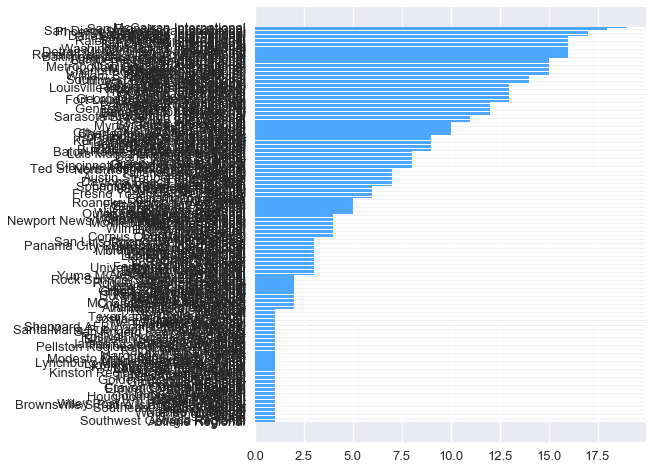

```python
fig = plt.figure(figsize=(7,8))
ax1 = fig.add_subplot(1,1,1)
plt.barh(airport_count_carriers_df.airport,airport_count_carriers_df.CarriersCount);
```

- I have to many airport rows -- around 280s rows.
- Therefore need alternative plots other than barh to visualize data.
- Getting better visualization with scatter plot. But plotly is much better. Here is the link.

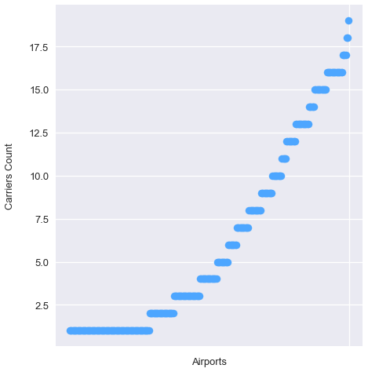

```python
fig = plt.figure(figsize=(7,8))
ax1 = fig.add_subplot(1,1,1)
plt.scatter(airport_count_carriers_df.airport,airport_count_carriers_df.CarriersCount)
plt.xticks('');
plt.ylabel('Carriers Count\n',fontsize=13)
plt.xlabel('Airports',fontsize=13);
```

- Please click **Edit Chart** to view the plotly map online or Please click Refresh on your web browser.

```python
airport_count_carriers_df['text'] = airport_count_carriers_df['airport'] + '' + airport_count_carriers_df['city'] +\
    ', ' + airport_count_carriers_df['state'] + '' + 'Count: ' + airport_count_carriers_df['CarriersCount'].astype(str)

scl = [ [0,"rgb(5, 10, 172)"],[0.35,"rgb(40, 60, 190)"],[0.5,"rgb(70, 100, 245)"],\
    [0.6,"rgb(90, 120, 245)"],[0.7,"rgb(106, 137, 247)"],[1,"rgb(220, 220, 220)"] ]

data = [ dict(
        type = 'scattergeo',
        locationmode = 'USA-states',
        lon = airport_count_carriers_df['long'],
        lat = airport_count_carriers_df['lat'],
        text = airport_count_carriers_df['text'],
        mode = 'markers',
        marker = dict(
            size = 10,
            opacity = 0.8,
            reversescale = True,
            autocolorscale = False,
            symbol = 'round',
            line = dict(
                width=1,
                color='rgba(102, 102, 102)'
            ),
            colorscale = scl,
            cmin = 1,
            color = airport_count_carriers_df['CarriersCount'],
            cmax = airport_count_carriers_df['CarriersCount'].max(),
            colorbar=dict(
                title="Number of Airline Carriers"
            )
        ))
       ]

layout = dict(
        title = 'Number of Airline Carriers Operating in an Airport<br>(Hover for airport names)',
        colorbar = True,
        geo = dict(
            scope='usa',
            projection=dict( type='albers usa' ),
            showland = True,
            landcolor = "rgb(250, 250, 250)",
            subunitcolor = "rgb(217, 217, 217)",
            countrycolor = "rgb(217, 217, 217)",
            countrywidth = 0.5,
            subunitwidth = 0.5
        ),
    )

fig = dict( data=data, layout=layout )
py.iplot( fig, validate=False, filename='andy-airports-origin' )
```

[interactive chart not shown]

- From the map above, most airports cluster on the East coast.
- plotly map is a much better **map** visualization tool than barh and scatter plot.
- Please click **Edit Chart** to view the plotly map online or Please click Refresh on your web browser.

```python
airport_count_carriers_df['text'] = airport_count_carriers_df['airport'] + '' + airport_count_carriers_df['city'] +\
    ', ' + airport_count_carriers_df['state'] + '' + 'Count: ' + airport_count_carriers_df['CarriersCount'].astype(str)

scl = [ [0,"rgb(5, 10, 172)"],[0.35,"rgb(40, 60, 190)"],[0.5,"rgb(70, 100, 245)"],\
    [0.6,"rgb(90, 120, 245)"],[0.7,"rgb(106, 137, 247)"],[1,"rgb(220, 220, 220)"] ]

data = [ dict(
        type = 'scattergeo',
        locationmode = 'USA-states',
        lon = airport_count_carriers_df['long'],
        lat = airport_count_carriers_df['lat'],
        text = airport_count_carriers_df['text'],
        mode = 'markers',
        marker = dict(
            size = 10,
            opacity = 0.8,
            reversescale = True,
            autocolorscale = False,
            symbol = 'round',
            line = dict(
                width=1,
                color='rgba(102, 102, 102)'
            ),
            colorscale = scl,
            cmin = 10,
            color = airport_count_carriers_df['CarriersCount'],
            cmax = airport_count_carriers_df['CarriersCount'].max(),
            colorbar=dict(
                title="Numbe of Airline Carriers"
            )
        ))

       ]

layout = dict(
        title = 'Number of Airline Carriers Operating in an Airport<br>cmin=10 -- only airports with 10 carriers will be shown in blue<br>(Hover for airport names)',
        colorbar = True,
        geo = dict(
            scope='usa',
            projection=dict( type='albers usa' ),
            showland = True,
            landcolor = "rgb(250, 250, 250)",
            subunitcolor = "rgb(217, 217, 217)",
            countrycolor = "rgb(217, 217, 217)",
            countrywidth = 0.5,
            subunitwidth = 0.5
        ),
    )

fig = dict( data=data, layout=layout )
py.iplot( fig, validate=False, filename='andy-airports2-origin' )
```

[interactive chart not shown]

- With cmin=10, only airports with at least 10 carriers will have blue colors.
- Most of the big-size airports (airport carrying 10 or more Airline Carriers) locate along the eastern and western coastal cities and border lines - border line with Canada and Mexico. A few big airports locate in the central USA. You can **NOT** see this relationship by looking at airport barh plot drawn previously

# Bivariate Exploration

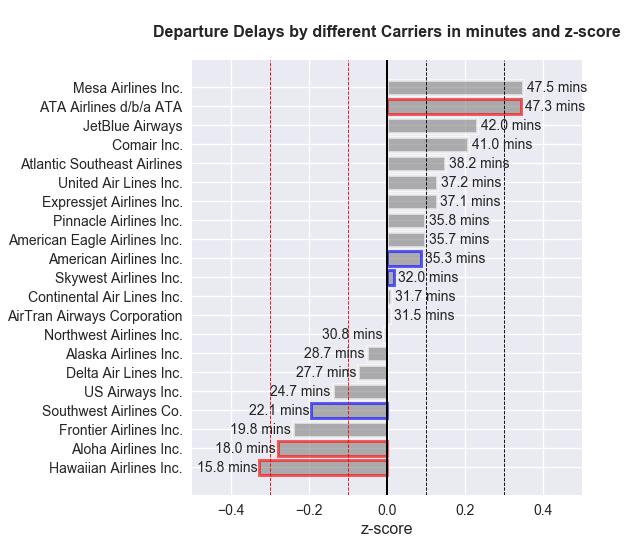

```python
# Data from table above
fig = plt.figure(figsize=[7,8])
ax1 = fig.add_subplot(1,1,1)
#plt.barh(list(pos_z_series.index),pos_z_series.values,color=colors)

plt.barh(list(pos_z_dep_series.index),pos_z_dep_series.values,edgecolor=colors_edge,color=colors,alpha=0.6,linewidth=3)

plt.axvline(-0.1,color='red',linewidth=0.9,linestyle='--')
plt.axvline(-0.3,color='red',linewidth=0.9,linestyle='--')
plt.axvline(0,color='black',linewidth=2)
plt.axvline(0.1,color='black',linewidth=0.9,linestyle='--')
plt.axvline(0.3,color='black',linewidth=0.9,linestyle='--')

plt.title('\nDeparture Delays by different Carriers in minutes and z-score\n',fontsize=16,weight='bold')
plt.xlim(-0.5,0.5)
plt.xlabel('z-score',fontsize=16)
plt.xticks(fontsize=14)
plt.yticks(fontsize=14)

for i in range(pos_min_dep_series.shape[0]):
    val = pos_min_dep_series.values[i]  # this is in minutes
    x_val = pos_z_dep_series.values[i]  # this is z-score
    val_str = '{:0.1f} mins'.format(val)
    if x_val > 0:
        plt.text(x=x_val+0.01,y=i,s=val_str,va='center',fontsize=14,)
    else:
        plt.text(x=x_val-0.16,y=i,s=val_str,va='center',fontsize=14)
```

**I also added an extra information to the plot -- Carrier Distribution information**

- Bars with the blue edge are the top three Carriers in terms of number of flights in the data. The top three Carriers having the largest number of flights are: Skywest Airlines, American Airlines and Southwest Airlines in ascending order. These airlines perform really well considering the large number of flights they operate and having relativley low z-score Delay.
- Bars with the red edge are the bottom three Carriers in terms of number of flights in the data. The bottom three Carriers are: Hawaiian Airlines, Aloha Airlines and ATA Airlines in ascending order. Aloha Airlines and Hawaiian Airlines have the lowest mean of Departure Delays. This is expected since they have one of the lowest number of flights in the data -- only about 0.4% and 0.8%, respectively. ATA Airlines performance is dismal. It has the second highest mean Departure Delay although it makes up of only 0.1% of total flight!

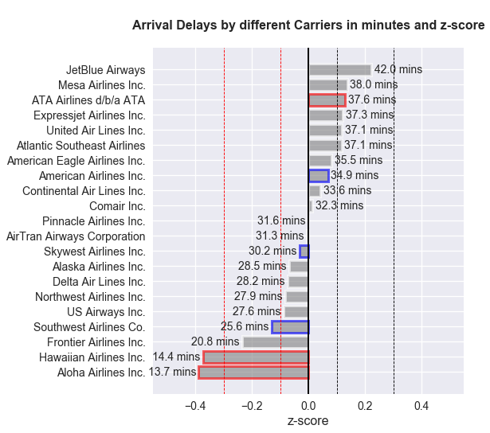

```python
# Data from table above
fig = plt.figure(figsize=[7,8])
ax1 = fig.add_subplot(1,1,1)
plt.barh(list(pos_z_arr_series.index),pos_z_arr_series.values,edgecolor=colors_edge,color=colors,alpha=0.6,linewidth=3)

plt.axvline(-0.1,color='red',linewidth=0.9,linestyle='--')
plt.axvline(-0.3,color='red',linewidth=0.9,linestyle='--')
plt.axvline(0,color='black',linewidth=2)
plt.axvline(0.1,color='black',linewidth=0.9,linestyle='--')
plt.axvline(0.3,color='black',linewidth=0.9,linestyle='--')

plt.title('\nArrival Delays by different Carriers in minutes and z-score\n',fontsize=16,weight='bold')
plt.xlim(-0.55,0.55)
plt.xlabel('z-score',fontsize=16)
plt.xticks(fontsize=14)
plt.yticks(fontsize=14)

for i in range(pos_min_arr_series.shape[0]):
    val = pos_min_arr_series.values[i]  # this is in minutes
    x_val = pos_z_arr_series.values[i]  # this is z-score
    val_str = '{:0.1f} mins'.format(val)
    if x_val > 0:
        plt.text(x=x_val+0.01,y=i,s=val_str,va='center',fontsize=14,)
    else:
        plt.text(x=x_val-0.18,y=i,s=val_str,va='center',fontsize=14)
```

**I also added an extra information to the plot -- Carrier Distribution information**

- Bars with the blue edge are the top three Carriers in terms of number of flights in the data. The top three Carriers having the largest number of flights are: Skywest Airlines, American Airlines and Southwest Airlines in ascending order. These airlines perform really well considering the large number of flights they operate and having relativley low z-score Delay.
- Bars with the red edge are the bottom three Carriers in terms of number of flights in the data. The bottom three Carriers are: Hawaiian Airlines, Aloha Airlines and ATA Airlines in ascending order. Aloha Airlines and Hawaiian Airlines have the lowest mean of Arrival Delays. This is expected since they have one of the lowest number of flights in the data -- only about 0.4% and 0.8%, respectively. ATA Airlines performance is dismal. It has the third highest mean Arrival Delay although it makes up of only 0.1% of total flight!

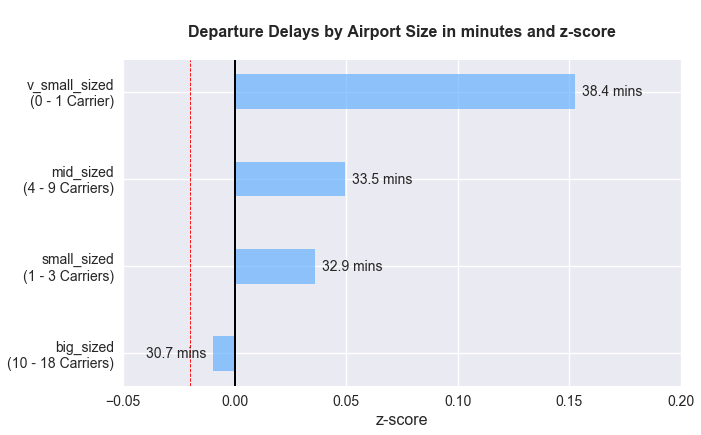

```python
# Data from table above
fig = plt.figure(figsize=[10,6])
ax1 = fig.add_subplot(1,1,1)
#plt.barh(list(pos_z_series.index),pos_z_series.values,color=colors)

plt.barh(list(pos_z_dep_air_series.index),pos_z_dep_air_series.values,alpha=0.6,height=0.4)

plt.axvline(0,color='black',linewidth=2)
plt.axvline(-0.02,color='red',linewidth=0.9,linestyle='--')

plt.title('\nDeparture Delays by Airport Size in minutes and z-score\n',fontsize=16,weight='bold')
plt.xlim(-0.05,0.2)
plt.xlabel('z-score',fontsize=16)
plt.xticks(fontsize=14)
#plt.yticks(pos_z_dep_air_series.index,['a','b','c','d'],fontsize=16)
plt.yticks(pos_z_dep_air_series.index,airport_cat_list,fontsize=14)

for i in range(pos_mean_dep_air_series.shape[0]):
    val = pos_mean_dep_air_series.values[i]
    x_val = pos_z_dep_air_series.values[i]
    #print(val)
    val_str = '{:0.1f} mins'.format(val)
    #print(val_str)
    if x_val > 0:
        plt.text(x=x_val+0.003,y=i,s=val_str,va='center',fontsize=14,)
    else:
        plt.text(x=x_val-0.03,y=i,s=val_str,va='center',fontsize=14)
```

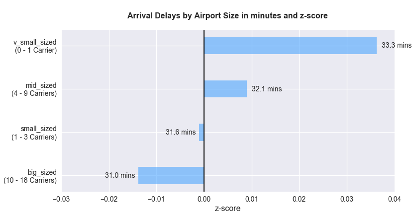

```python
# Data from table above
fig = plt.figure(figsize=[12,6])
ax1 = fig.add_subplot(1,1,1)
#plt.barh(list(pos_z_series.index),pos_z_series.values,color=colors)

plt.barh(list(pos_z_arr_air_series.index),pos_z_arr_air_series.values,alpha=0.6,height=0.4)

plt.axvline(0,color='black',linewidth=2)
#plt.axvline(-0.02,color='red',linewidth=0.9,linestyle='--')

plt.title('\nArrival Delays by Airport Size in minutes and z-score\n',fontsize=16,weight='bold')
plt.xlim(-0.03,0.04)
plt.xlabel('z-score',fontsize=16)
plt.xticks(fontsize=14)
#plt.yticks(pos_z_dep_air_series.index,['a','b','c','d'],fontsize=16)
plt.yticks(pos_z_arr_air_series.index,airport_cat_list,fontsize=14)

for i in range(pos_mean_arr_air_series.shape[0]):
    val = pos_mean_arr_air_series.values[i]
    x_val = pos_z_arr_air_series.values[i]
    #print(val)
    val_str = '{:0.1f} mins'.format(val)
    #print(val_str)
    if x_val > 0:
        plt.text(x=x_val+0.001,y=i,s=val_str,va='center',fontsize=14,)
    else:
        plt.text(x=x_val-0.007,y=i,s=val_str,va='center',fontsize=14)
```

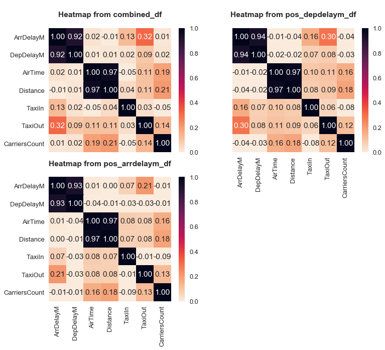

```python
fig = plt.figure(figsize=[12,10])

ax1 = fig.add_subplot(2,2,1)
sb.heatmap(combined_df[desired_cols].corr(),annot=True,cmap='rocket_r',fmt='.2f',vmin=0)
plt.title('\nHeatmap from combined_df\n',weight='bold');
plt.xticks([])

ax2 = fig.add_subplot(2,2,2)
sb.heatmap(pos_depdelaym_df[desired_cols].corr(),annot=True,cmap='rocket_r',fmt='.2f',vmin=0)
plt.title('\nHeatmap from pos_depdelaym_df\n',weight='bold');
plt.yticks([])

ax3 = fig.add_subplot(2,2,3)
sb.heatmap(pos_arrdelaym_df[desired_cols].corr(),annot=True,cmap='rocket_r',fmt='.2f',vmin=0)
plt.title('\nHeatmap from pos_arrdelaym_df\n',weight='bold');
```

- By looking at heatmaps (derived from combined_df, pos_depdelaym_df, and pos_arrdelaym_df) above, there isn't any significant relationship between DepDelayM/ArrDelayM and AirTime, Distance, TaxiIn, TaxiOut, CarriersCount.
- There is a small relationship between TaxiOut and ArrDelayM in combined_df and pos_depdelaym_df. However, I expect TaxiIn to be related to ArrDelayM and TaxiOut related to DepDelayM. I need insider knowledge to know if there is relationship between TaxiOut and ArrDelayM.
- Therefore, I will not investigate AirTime, Distance, TaxiIn, TaxiOut further.

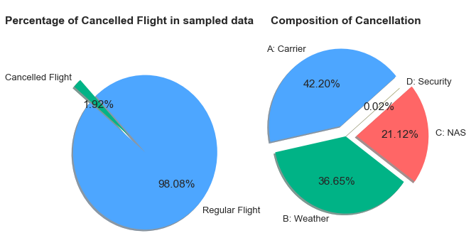

```python
fig = plt.figure(figsize=[10,5])


ax1 = fig.add_subplot(1,2,1)
colors = [my_palette[0], my_palette[2]]
explode = (0.3, 0)  # explode 1st slice
labels = ['Regular Flight','Cancelled Flight']
plt.pie(data,autopct='%1.2f%%',shadow=True,explode=explode,labels=labels,startangle=140)
plt.title('\nPercentage of Cancelled Flight in sampled data\n',weight='bold')

ax2 = fig.add_subplot(1,2,2)
explode = (0.15, 0, 0.15, 0)  # explode 1st slice
labels =['A: Carrier','B: Weather','C: NAS','D: Security']
#colors = ['gold', 'yellowgreen', 'lightcoral', 'lightskyblue']
plt.pie(cancelled_series,autopct='%1.2f%%',explode=explode,shadow=True,colors=my_palette,startangle=40,labels=labels)
plt.title('\nComposition of Cancellation\n',weight='bold')

plt.show()
```

- Plot 1 above shows that Cancelled Flight is 1.92% of total flight. This represents around 4,100 number of flights. Regular (non-cancelled flight) is around 98% of total flight.
- Plot 2 above shows the composition of Cancellation.

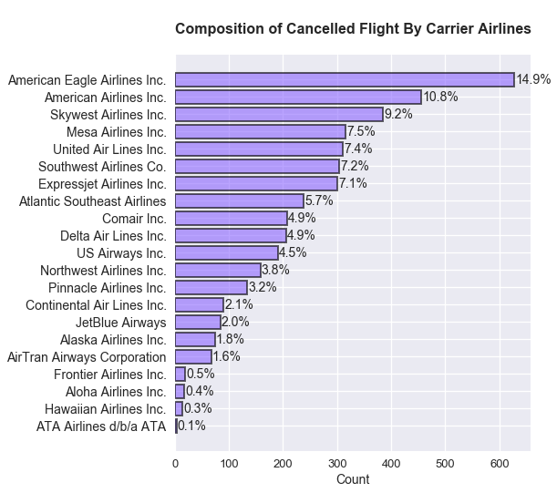

```python
fig = plt.figure(figsize=[7,8])
ax1 = fig.add_subplot(1,1,1)

plt.barh(list(carrier_cancelled_series.index),list(carrier_cancelled_series.values),\
        color=my_palette[4],alpha=0.6,edgecolor='black',linewidth=2)

plt.title('\nComposition of Cancelled Flight By Carrier Airlines\n',fontsize=16,weight='bold')
plt.yticks(fontsize=14)
plt.xlabel('Count',fontsize=14)

for i in range(c_cancelled_pct_series.shape[0]):
    val = c_cancelled_pct_series.values[i]  # percent
    x_val = carrier_cancelled_series.values[i] # in count
    val_str = '{:0.1f}%'.format(val)

    plt.text(x=x_val+2,y=i,s=val_str,va='center',fontsize=14)

plt.show()
```

- Plot above shows percentage of Cancelled Flight by Airline Carriers in horizontal bar. (This is a univariate plot)

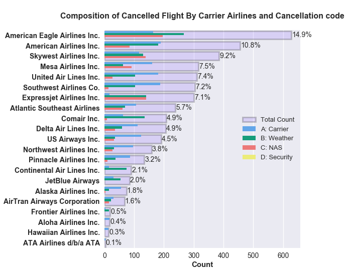

```python
fig = plt.figure(figsize=[7,8])
ax1 = fig.add_subplot(1,1,1)

plt.barh(manual_cancelled,cnt_list,\
        color=my_palette[4],alpha=0.2,edgecolor='black',linewidth=3)
sb.countplot(data=cancelled_df,y='CarrierDescription',hue='CancellationCode',\
             order=cancelled_df.CarrierDescription.value_counts().index)

plt.title('\nComposition of Cancelled Flight By Carrier Airlines and Cancellation code\n',fontsize=16,weight='bold')
plt.legend(labels=['Total Count','A: Carrier','B: Weather','C: NAS','D: Security'])
plt.ylabel('')
plt.yticks(fontsize=14,weight='bold')
plt.xlabel('Count',fontsize=15,weight='bold')
plt.xticks(fontsize=14)

for i in range(manual_cancelled.shape[0]):
    pct = cancelled_df[cancelled_df.CarrierDescription==manual_cancelled[i]].shape[0]/cancelled_df.shape[0]*100
    x_val = cnt_list[i]
    #print(pct)
    val_str = '{:0.1f}%'.format(pct)
    #print(val_str)
    plt.text(x=x_val+2,y=i,s=val_str,va='center',fontsize=14)
plt.show()
```

- The plot above not only shows percentage of cancellation by Airline Carriers but also show the composition of Cancellation code.

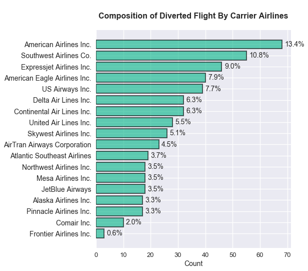

```python
fig = plt.figure(figsize=[7,8])
ax1 = fig.add_subplot(1,1,1)

plt.barh(list(diverted_series.index),list(diverted_series.values),color=my_palette[1],\
        alpha=0.6,edgecolor='black',linewidth=2)

plt.title('\nComposition of Diverted Flight By Carrier Airlines\n',fontsize=16,weight='bold')
plt.yticks(fontsize=14)
plt.xlabel('Count',fontsize=14)

for i in range(diverted_pct_series.shape[0]):
    val = diverted_pct_series[i]
    x_val = diverted_series.values[i]
    val_str = '{:0.1f}%'.format(val)
    #print(val_str)
    plt.text(x=x_val+1,y=i,s=val_str,va='center',fontsize=14)

plt.show();
```

- The plot above shows the composition of Diverted Flight by Airline Carriers in bar horizontal plot. (This is a univariate plot)

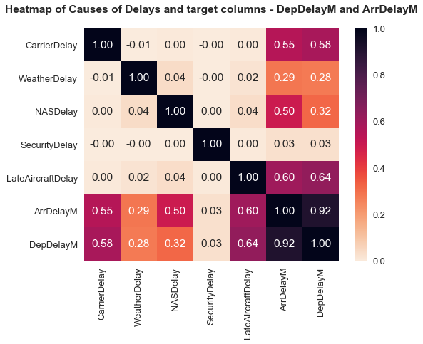

```python
fig = plt.figure(figsize=(8,6))
ax1 = fig.add_subplot(1,1,1)
sb.heatmap(combined_df[cols_delays].corr(),annot=True,cmap='rocket_r',fmt='.2f',vmin=0);
plt.title('Heatmap of Causes of Delays and target columns - DepDelayM and ArrDelayM\n',weight='bold');
```

- By looking at this heatmap, there is a relationship between casuses of delays (CarrierDelay, NASDelay, LateAircarftDelay) and our target features -- DepDelay and ArrDelay. WeatherDelay and SecurityDelay have weak relationship however. I will discuss this relationship further in Section 5.

# Multivariate Exploration

## Converted Ordinal Variable

- Because we use these ordinal variables extensively in multivariate exploration, I reproduce here for reference.

**DepTimeCategory and ArrTimeCategory**:  
-- 24:00 (not 00:00) -- 02:59: Late Night  
-- 03:00 -- 05:59: Early Morning  
-- 06:00 -- 08:59: Morning  
-- 09:00 -- 11:59: Late Morning  
-- 12:00 -- 14:59: Afternoon  
-- 15:00 -- 17:59: Late Afternoon  
-- 18:00 -- 20:59: Evening  
-- 21:00 -- 23:59: Night

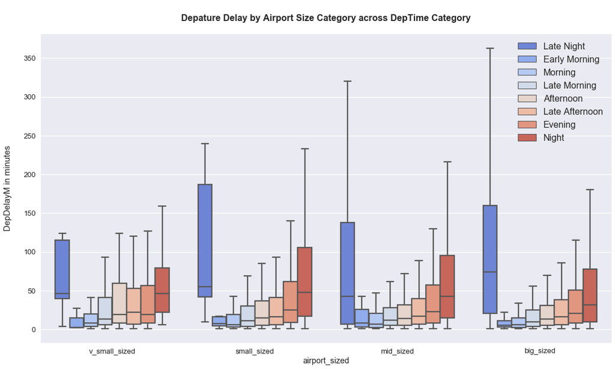

```python
fig = plt.figure(figsize=(18,10))
ax1 = fig.add_subplot(1,1,1)
sb.boxplot(data=pos_depdelaym_df,y=pos_depdelaym_df.DepDelayM,x=pos_depdelaym_df.airport_sized,hue='DepTimeCategory'\
          ,showfliers=False,palette='coolwarm')

plt.title('\nDepature Delay by Airport Size Category across DepTime Category\n',fontsize=16,\
                 weight='bold')
#plt.ylim(-30,230);
plt.ylabel('DepDelayM in minutes\n',fontsize=15)
plt.legend(fontsize=16);
```

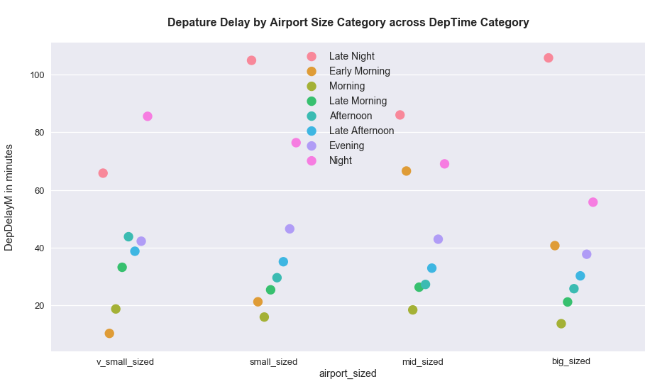

```python
fig = plt.figure(figsize=(15,8))
ax1 = fig.add_subplot(1,1,1)
sb.pointplot(data=pos_depdelaym_df,y=pos_depdelaym_df.DepDelayM,x=pos_depdelaym_df.airport_sized,hue='DepTimeCategory',ci=None,
            linestyles='',dodge=0.3)

plt.title('\nDepature Delay by Airport Size Category across DepTime Category\n',fontsize=16,\
                 weight='bold')
plt.ylabel('DepDelayM in minutes\n',fontsize=15)
plt.legend(fontsize=14);
```

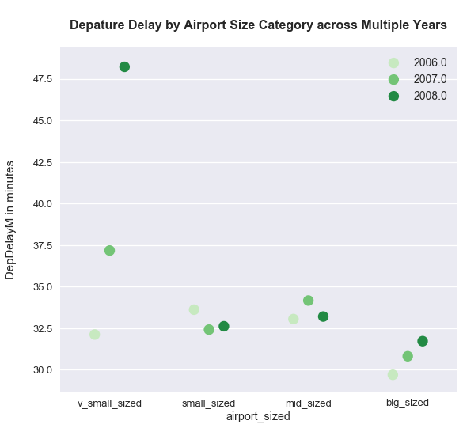

```python
fig = plt.figure(figsize=(9,8))
ax1 = fig.add_subplot(1,1,1)
sb.pointplot(data=pos_depdelaym_df,y=pos_depdelaym_df.DepDelayM,x=pos_depdelaym_df.airport_sized,\
             hue=pos_depdelaym_df.DepTime.dt.year,ci=None,linestyles='',dodge=0.3,palette='Greens')

plt.title('\nDepature Delay by Airport Size Category across Multiple Years\n',fontsize=16,\
                 weight='bold')
plt.ylabel('DepDelayM in minutes\n',fontsize=15)
plt.legend(fontsize=14);
```

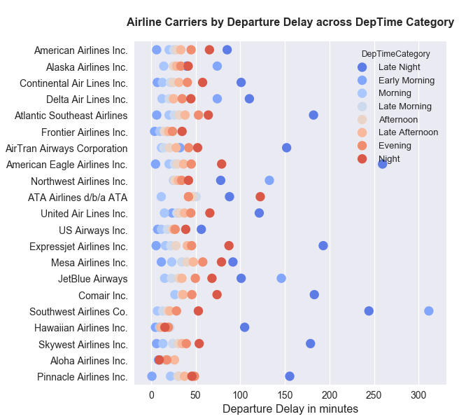

```python
fig = plt.figure(figsize=(8,9))
ax1 = fig.add_subplot(1,1,1)
sb.pointplot(data=pos_depdelaym_df,x='DepDelayM',y='CarrierDescription',ci=None,\
             linestyles='',hue='DepTimeCategory',palette='coolwarm')
#sb.pointplot(data=pos_arrdelaym_df,x='z_ArrDelayM',y='CarrierDescription',ci='sd',linestyles='',color=my_palette[4],capsize=.5)
plt.title('\nAirline Carriers by Departure Delay across DepTime Category\n',fontsize=16,\
                 weight='bold')#plt.axvline(0,color='black')
plt.ylabel('')
plt.yticks(fontsize=14)
plt.xlabel('Departure Delay in minutes',fontsize=16)
plt.xticks(fontsize=14)
plt.show()
```

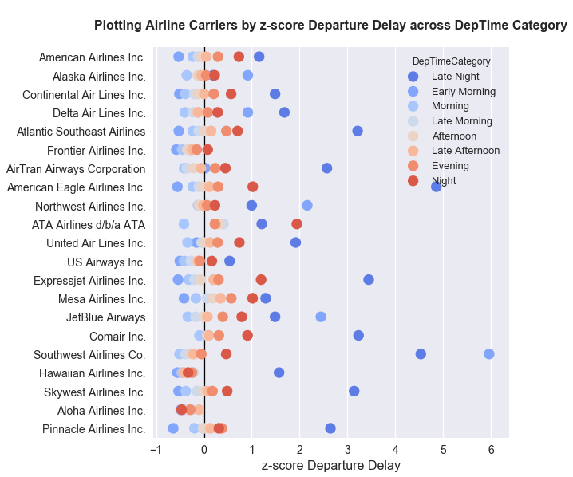

```python
fig = plt.figure(figsize=(8,9))
ax1 = fig.add_subplot(1,1,1)
sb.pointplot(data=pos_depdelaym_df,x='z_DepDelayM',y='CarrierDescription',ci=None,\
             linestyles='',hue='DepTimeCategory',palette='coolwarm')
#sb.pointplot(data=pos_arrdelaym_df,x='z_ArrDelayM',y='CarrierDescription',ci='sd',linestyles='',color=my_palette[4],capsize=.5)

plt.title('\nPlotting Airline Carriers by z-score Departure Delay across DepTime Category\n',fontsize=16,\
                 weight='bold')
plt.axvline(0,color='black')
plt.ylabel('')
plt.yticks(fontsize=14)
plt.xlabel('z-score Departure Delay',fontsize=16)
plt.xticks(fontsize=14)
plt.show()
```

#### Observations on two plots above based on `pos_depdelaym_df` dataframe:

- The first plot on the x-axis is `DepDelay in minutes` and the x-axis on the second plot is `z-score of DepDelayM`.
- Longest departure delays happen mostly at 'Late Night' and 'Early Morning'. This happened two standard deveations above the mean.
- Shortest Departure Delays happened in `Morning` and `Late Morning` across almost all Airline Carriers except for Aloha Airlines Inc.
- Note the cascading delays. Starting shortest in the morning / late morning and ending the longest at Late Night and Early Morning.

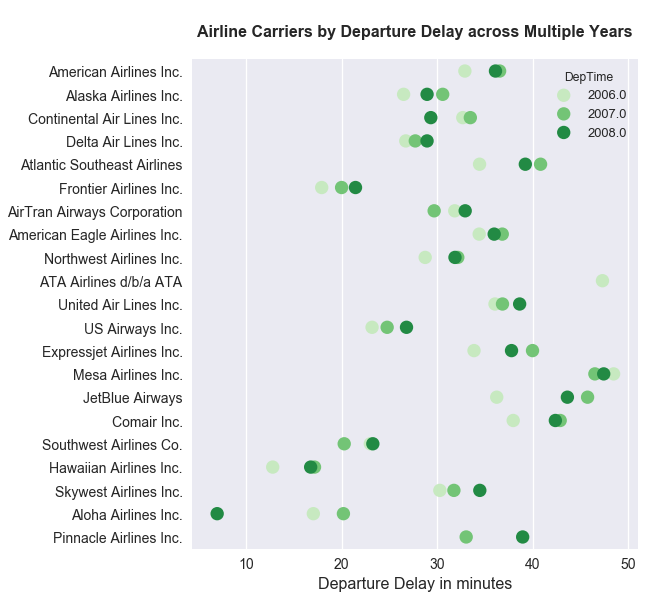

```python
fig = plt.figure(figsize=(8,9))
ax1 = fig.add_subplot(1,1,1)
sb.pointplot(data=pos_depdelaym_df,x='DepDelayM',y='CarrierDescription',ci=None,\
             linestyles='',hue=pos_depdelaym_df.DepTime.dt.year,palette='Greens',ax=ax1)
#sb.pointplot(data=pos_arrdelaym_df,x='z_ArrDelayM',y='CarrierDescription',ci='sd',linestyles='',color=my_palette[4],capsize=.5)

plt.title('\nAirline Carriers by Departure Delay across Multiple Years\n',fontsize=16,\
                 weight='bold')
#plt.axvline(0,color='black')
plt.ylabel('')
plt.yticks(fontsize=14)
plt.xlabel('Departure Delay in minutes',fontsize=16)
plt.xticks(fontsize=14)
plt.show()
```

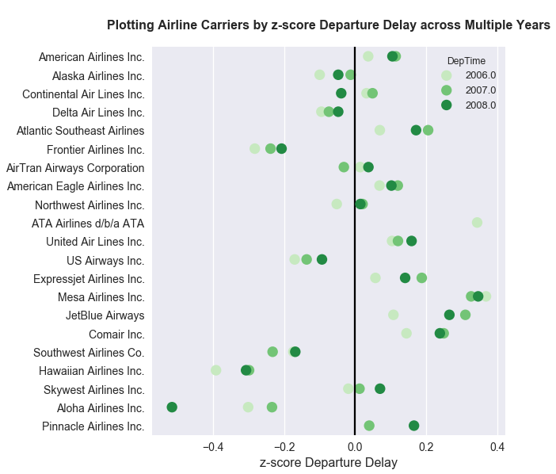

```python
fig = plt.figure(figsize=(8,9))
ax1 = fig.add_subplot(1,1,1)
sb.pointplot(data=pos_depdelaym_df,x='z_DepDelayM',y='CarrierDescription',ci=None,\
             linestyles='',hue=pos_depdelaym_df.DepTime.dt.year,palette='Greens',ax=ax1)
#sb.pointplot(data=pos_arrdelaym_df,x='z_ArrDelayM',y='CarrierDescription',ci='sd',linestyles='',color=my_palette[4],capsize=.5)

plt.title('\nPlotting Airline Carriers by z-score Departure Delay across Multiple Years\n',fontsize=16,\
                 weight='bold')
plt.axvline(0,color='black')
plt.ylabel('')
plt.yticks(fontsize=14)
plt.xlabel('z-score Departure Delay',fontsize=16)
plt.xticks(fontsize=14)
plt.show()
```

#### Observations on two plots above based on `pos_depdelaym` dataframe:

- The first plot on the x-axis is `DepDelay in minutes` and the x-axis on the second plot is `z-score of DepDelayM`.
- By eyeballing, longest Departure Delays happen mostly in 2007 and 2008.

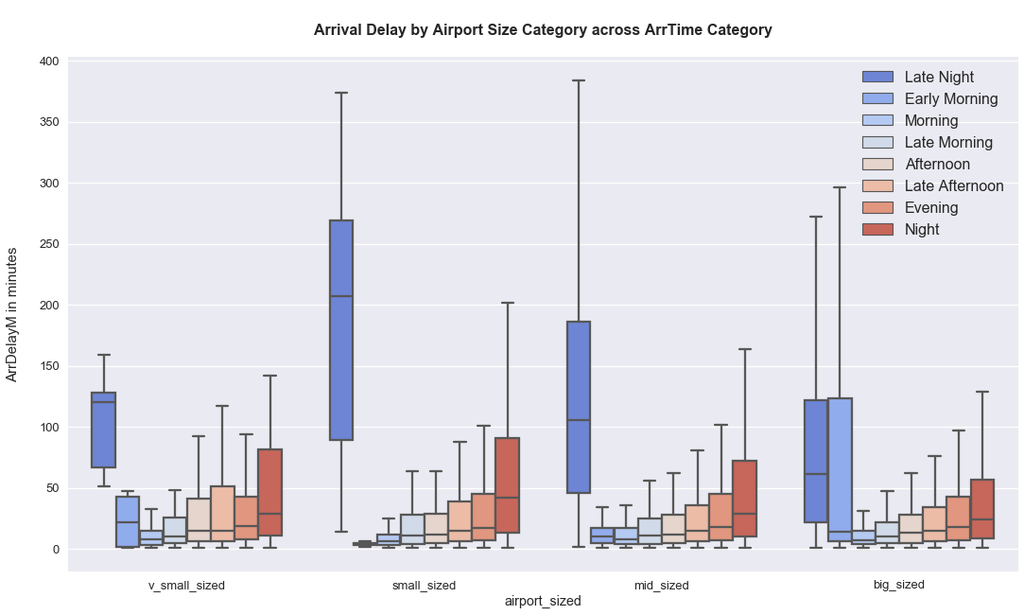

```python
fig = plt.figure(figsize=(18,10))
ax1 = fig.add_subplot(1,1,1)
sb.boxplot(data=pos_arrdelaym_df,y=pos_arrdelaym_df.ArrDelayM,x=pos_arrdelaym_df.airport_sized,hue='ArrTimeCategory'\
          ,showfliers=False,palette='coolwarm')

plt.title('\nArrival Delay by Airport Size Category across ArrTime Category\n',fontsize=16,\
                 weight='bold')
#plt.ylim(-30,230);
plt.ylabel('ArrDelayM in minutes\n',fontsize=15)
plt.legend(fontsize=16);
```

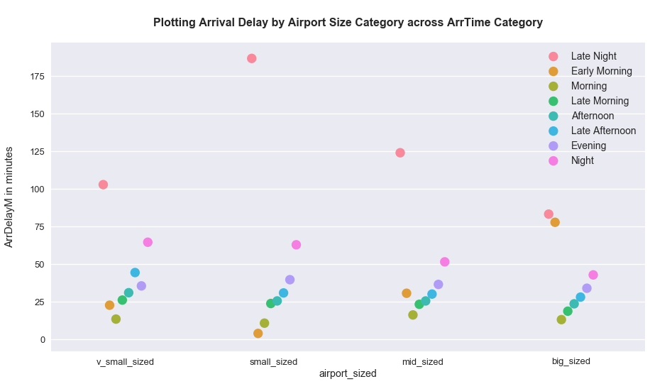

```python
fig = plt.figure(figsize=(15,8))
ax1 = fig.add_subplot(1,1,1)
sb.pointplot(data=pos_arrdelaym_df,y=pos_arrdelaym_df.ArrDelayM,x=pos_arrdelaym_df.airport_sized,\
            hue='ArrTimeCategory',ci=None,linestyles='',dodge=0.3)

plt.title('\nPlotting Arrival Delay by Airport Size Category across ArrTime Category\n',fontsize=16,\
                 weight='bold')
plt.ylabel('ArrDelayM in minutes\n',fontsize=15)
plt.legend(fontsize=14);
```

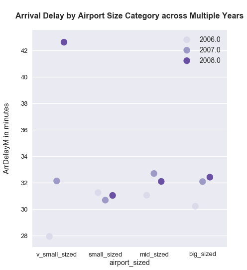

```python
fig = plt.figure(figsize=(7,8))
ax1 = fig.add_subplot(1,1,1)
sb.pointplot(data=pos_arrdelaym_df,y=pos_arrdelaym_df.ArrDelayM,x=pos_arrdelaym_df.airport_sized,\
             hue=pos_arrdelaym_df.ArrTime.dt.year,ci=None,linestyles='',dodge=0.3,palette='Purples')

plt.title('\nArrival Delay by Airport Size Category across Multiple Years\n',fontsize=16,\
                 weight='bold')
plt.ylabel('ArrDelayM in minutes\n',fontsize=15)
plt.legend(fontsize=14);
```

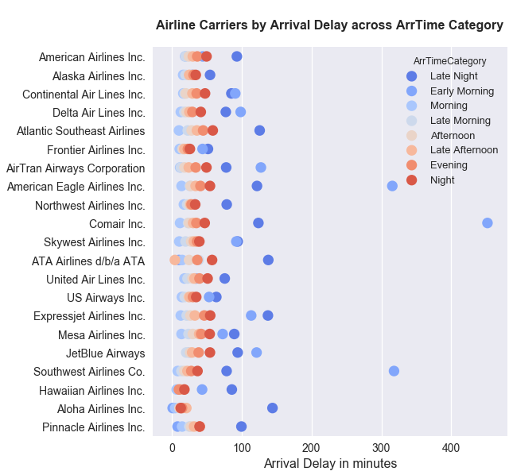

```python
fig = plt.figure(figsize=(8,9))
ax1 = fig.add_subplot(1,1,1)
sb.pointplot(data=pos_arrdelaym_df,x='ArrDelayM',y='CarrierDescription',ci=None,\
             linestyles='',hue='ArrTimeCategory',palette='coolwarm')
#sb.pointplot(data=pos_arrdelaym_df,x='z_ArrDelayM',y='CarrierDescription',ci='sd',linestyles='',color=my_palette[4],capsize=.5)

plt.title('\nAirline Carriers by Arrival Delay across ArrTime Category\n',fontsize=16,weight='bold')
#plt.axvline(0,color='black')
plt.ylabel('')
plt.yticks(fontsize=14)
plt.xlabel('Arrival Delay in minutes',fontsize=16)
plt.xticks(fontsize=14)
plt.show()
```

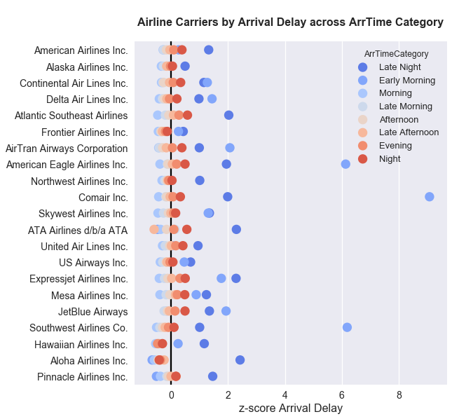

```python
fig = plt.figure(figsize=(8,9))
ax1 = fig.add_subplot(1,1,1)
sb.pointplot(data=pos_arrdelaym_df,x='z_ArrDelayM',y='CarrierDescription',ci=None,\
             linestyles='',hue='ArrTimeCategory',palette='coolwarm')
#sb.pointplot(data=pos_arrdelaym_df,x='z_ArrDelayM',y='CarrierDescription',ci='sd',linestyles='',color=my_palette[4],capsize=.5)

plt.title('\nAirline Carriers by Arrival Delay across ArrTime Category\n',fontsize=16,weight='bold')
plt.axvline(0,color='black')
plt.ylabel('')
plt.yticks(fontsize=14)
plt.xlabel('z-score Arrival Delay',fontsize=16)
plt.xticks(fontsize=14)
plt.show()
```

#### Observations on two plots above based on `pos_arrdelaym_df` dataframe:

- The first plot on the x-axis is `ArrDelay in minutes` and the x-axis on the second plot is `z-score of ArrDelayM`.
- Longest arrival delays happen mostly at 'Late Night' and 'Early Morning'. This happened two standard deveations above the mean.
- Shortest Departure Delays happened in `Morning` and `Late Morning` across almost all Airline Carriers except for Aloha Airlines Inc.
- Note the cascading delays. Starting shortest in the morning / late morning and ending the longest at Late Night and Early Morning.

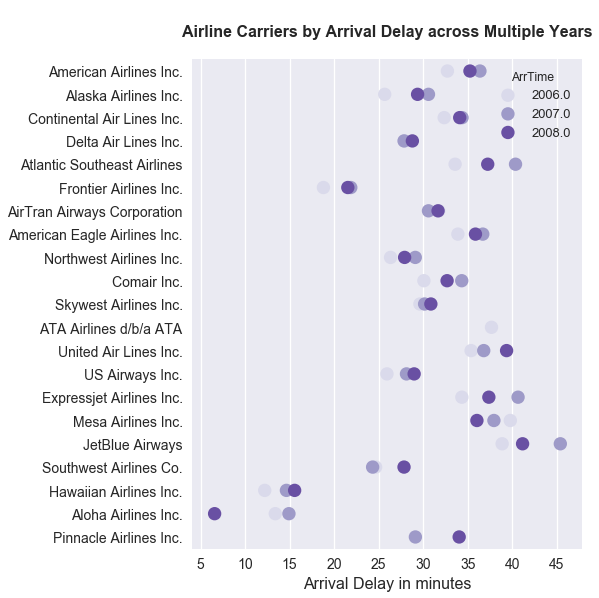

```python
fig = plt.figure(figsize=(7,9))
ax1 = fig.add_subplot(1,1,1)
sb.pointplot(data=pos_arrdelaym_df,x='ArrDelayM',y='CarrierDescription',ci=None,\
             linestyles='',hue=pos_arrdelaym_df.ArrTime.dt.year,palette='Purples',ax=ax1)
#sb.pointplot(data=pos_arrdelaym_df,x='z_ArrDelayM',y='CarrierDescription',ci='sd',linestyles='',color=my_palette[4],capsize=.5)

plt.title('\nAirline Carriers by Arrival Delay across Multiple Years\n',fontsize=16,\
                 weight='bold')
#plt.axvline(0,color='black')
plt.ylabel('')
plt.yticks(fontsize=14)
plt.xlabel('Arrival Delay in minutes',fontsize=16)
plt.xticks(fontsize=14)
plt.show()
```

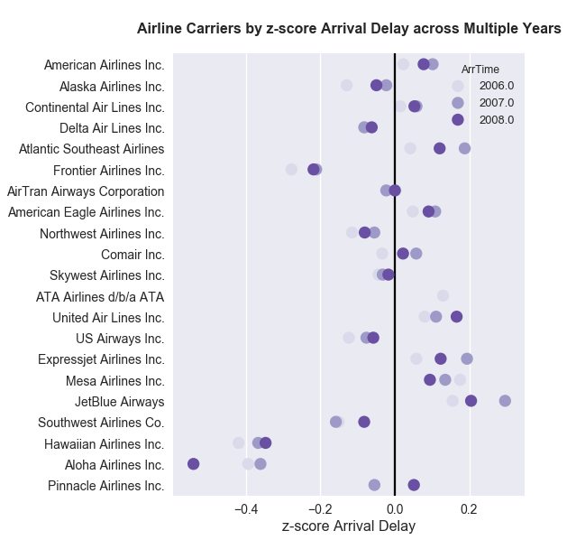

```python
fig = plt.figure(figsize=(7,9))
ax1 = fig.add_subplot(1,1,1)
sb.pointplot(data=pos_arrdelaym_df,x='z_ArrDelayM',y='CarrierDescription',ci=None,\
             linestyles='',hue=pos_arrdelaym_df.ArrTime.dt.year,palette='Purples',ax=ax1)
#sb.pointplot(data=pos_arrdelaym_df,x='z_ArrDelayM',y='CarrierDescription',ci='sd',linestyles='',color=my_palette[4],capsize=.5)

plt.title('\nAirline Carriers by z-score Arrival Delay across Multiple Years\n',fontsize=16,\
                 weight='bold')
plt.axvline(0,color='black')
plt.ylabel('')
plt.yticks(fontsize=14)
plt.xlabel('z-score Arrival Delay',fontsize=16)
plt.xticks(fontsize=14)
plt.show()
```

#### Observations on two plots above based on `pos_arrdelaym` dataframe:

- The first plot on the x-axis is `ArrDelay in minutes` and the x-axis on the second plot is `z-score of ArrDelayM`.
- By eyeballing, longest Arrival Delays happen mostly in 2007 and 2008.

## Drill Down

- From previous plots, we see a pattern. **MEAN** delays are lowest in the morning and highest late into the night. It seems as though delays are cascaded throughout the day.
- This section attempts to investigate if delays in a particular time category is carried over (cascaded) into the next time category. To do this, I have to track an individual flight number / tail number from early morning into night time.
- Because the queries do not fit nicely in this presentation, please refer to Section 5.5 of the jupyter notebook.